# simon-5510-13-slides

## Topics to be covered

- Scales of measurement
- Quality check of data
- Data transformations
- Descriptive statistics
- Graphs
- Linear regression
- Logistic regression
- Poisson regression
- Cox regression
- Longitudinal/hierarchical designs
- Analysis of qualitative data

## Measurement

- Traditional levels (scales) of measurement
  - Nominal
  - Ordinal
  - Interval
  - Ratio
- Special cases
  - Binary data
  - Count data, rate data
  - Time-to-event

## Ordinal verus interval controversy

- Sums of ordinal variables are meaningless
- Counterexample: grade point average
  - Shift from A to B versus a shift from D to F?
  - Two B’s equal and A plus a C?
- Purist versus pragmatist
- Is a sum of Likert scale items different?
  - Unequal scalings average out?

## Permissible statistical summaries

- Nominal: percentage, mode
- Ordinal: median
- Interval: mean, standard deviation
- Ratio: Coefficient of variation
- Special cases

## Permissible models

- Special cases
  - Binary: Logistic regression
  - Counts: Poisson regression
  - Time-to-event data: Cox proportional hazards regression
- Nominal: Chi-square tests, multinomial logistic regression
- Ordinal outcome variable: Non-parametric tests, ordinal logistic regression
- Ordinal indepdent variable” p for trend tests
- Interval/ratio: t-tests, analysis of variance, linear regression

## Break #1

- What you have learned
  - Scales of measurement
- What’s coming next
  - Quality check of data

## Steps in your data analysis

- Quality check of data
- Description of sample
- Test of hypotheses/research questions
- Additional exploratory analyses

## Quality check of your data (1/2)

- Completeness of data collection
- Review for responses that are ambiguous, out of range, etc
- Edit responses as needed
- Check response frequencies
  - Combine smaller categories, if needed

## Quality check of your data (2/2)

- Zero (or near-zero) variation
- Missing value count
- List five five rows, last five rows
- Correlations

## Data reduction

- Check composite scores
  - Check Cronbach’s alpha
  - Examine leaving out single items
  - Factor analysis, Structural Equations Modeling

## Break #2

- What you have learned
  - Quality check of data
- What’s coming next
  - Data transformations

## Data transformations

- Ideally selected a priori
  - Sometimes based on precedent
  - Sometimes motivated by theory
  - Sometimes based on empirical findings
- Don’t bother if your range is narrow
  - max/min <= 3
- Log transformation

## Log transformation

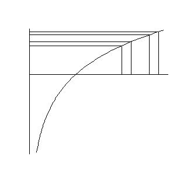

## Log transformation

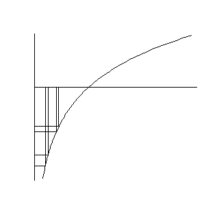

## Log transformation

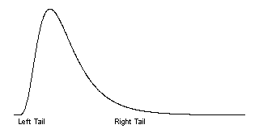

## Log transformation fixes

- Skewness
- Outliers
- Unequal variation
- Multiplicative models
  - log(ab) = log(a)+log(b)

## When should you use the log transformation?

- Data bounded below by zero.
  - Mean < Standard deviation
- Ratio data
- Max > 3*Min

## Log transformation

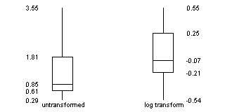

## Log transformation

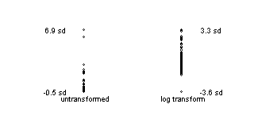

## Standard deviations, untransformed

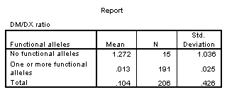

## Standard deviations, log transformed

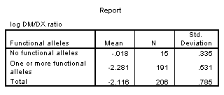

## Log transformation, summary

- Removes skewness
- Removes outliers
- Stabilizes variances
- Does not always work
- Best when
  - Data bounded below by zero
  - Mean < Standard deviation
  - Max/Min > 3

## Break #3

- What you have learned
  - Data transformations
- What’s coming next
  - Descriptive statistics

## Descriptive statistics

- Part of every quantitative study
- Table 1, overall summaries
  - Outcomes and covariates
  - Means and standard deviations for normal data
  - Median and interquartile range for skewed data
  - Percentages (always show denominator)
- Key subgroup comparisons
  - Crosstabulations
  - Means/standard deviations by subgroup

## Rules for crosstabulations

- Never display multiple statistics
- Place treatment/exposure categories in the rows
- Summarize using row percentages
- Many rows, not many columns
- Round liberally.

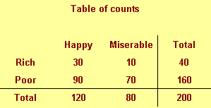

## Table of column percentages

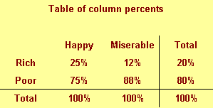

## Table of row percentages

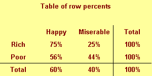

## Table of cell percentages

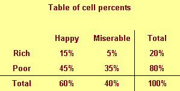

## Combining two numbers

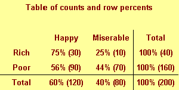

## Table of percentages

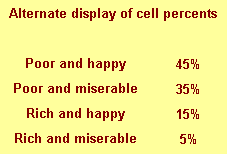

## Table of percentages

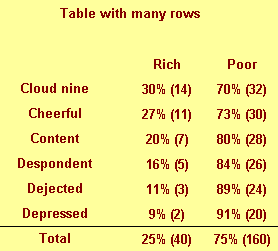

## Rules for crosstabulations

- Never display multiple statistics
- Place treatment/exposure categories in the rows
- Summarize using row percentages
- Many rows, not many columns
- Round liberally.

## Break #4

- What you have learned
  - Descriptive statistics
- What’s coming next
  - Graphs

## Graphs

- Overall summaries
  - Histograms for continuous data
  - Bar/pie charts for categorical data
- Assessing relationships
  - Side by side pie/bar charts
  - Boxplots
  - Scatterplots

## Histogram examples (1 of 3)

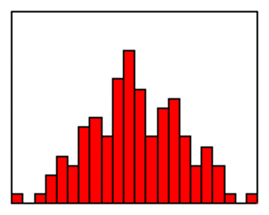

Histogram showing a roughly bell shaped curve

## Histogram examples (2 of 3)

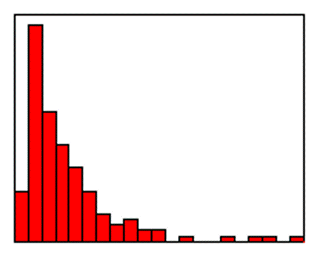

Histogram showing a skewed right distribution

## Histogram examples (3 of 3)

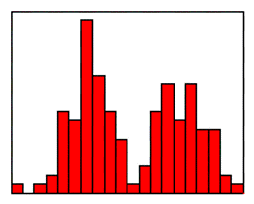

Histogram showing a bimodal distribution

## Side by side pie/bar charts

- Pies and bars only work well for 2 or 3 categories
  - Pacman charts
- No good graphs for more categories
- Avoid cheap 3D effects

## A very busy pie chart

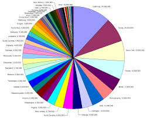

Pie chart of populations for all fifty states

## A bar chart

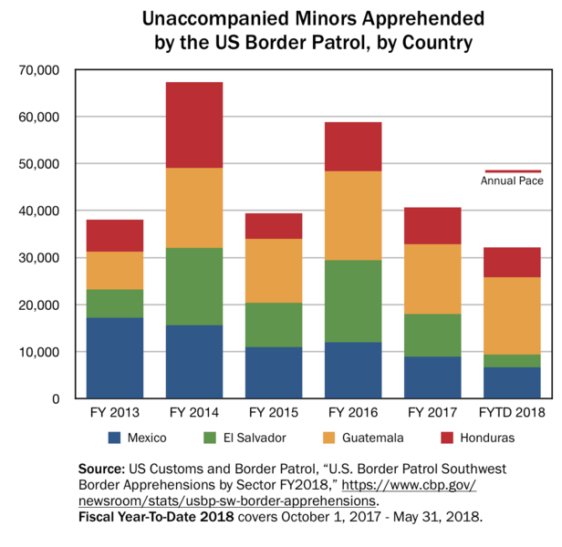

Bar chart showing country of orgin for unaccompanied minors

## A very busy bar chart

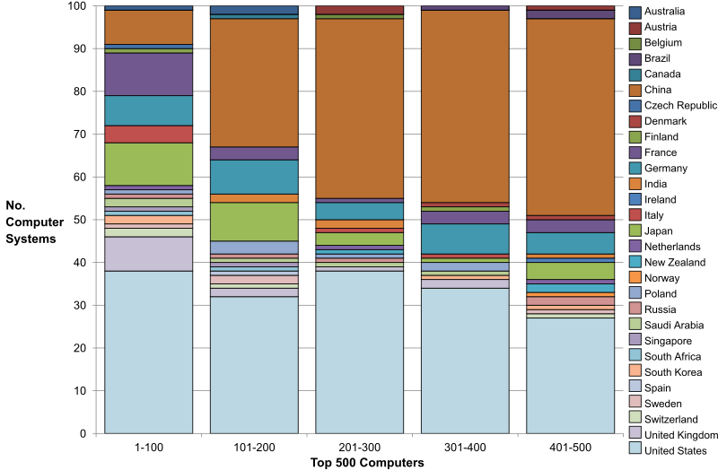

Bar chart showing distribution of computers across countries

## Boxplot

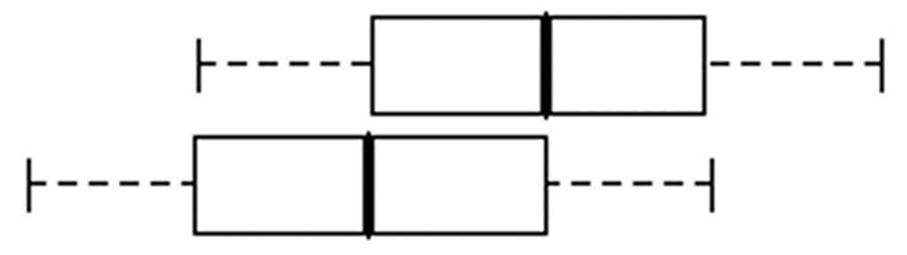

Image of two boxplots

## Scatterplot

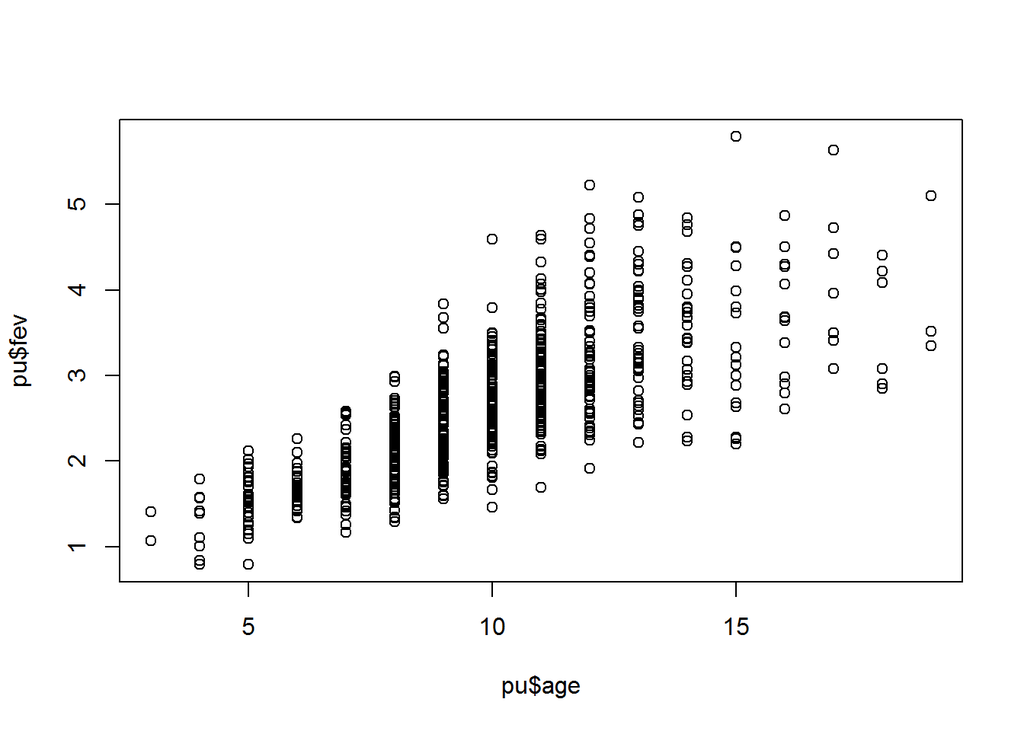

## Break #5

- What you have learned
  - Graphs
- What’s coming next
  - Linear regression

## Linear regression (1/2)

- Continuous outcome variable
- Very flexible
  - Either categorical or continuous independent variables
  - Multiple variables (risk adjustment)
  - Interactions
- Alternatives
  - t-test
  - Analysis of variance

## Linear regression (2/2)

- High school algebra
  - Y = m X + b
  - m = Δy / Δx
- The slope represents the estimated average change in Y when X increases by one unit.
- The intercept represents the estimated average value of Y when X equals zero.

## Age vs duration - graph

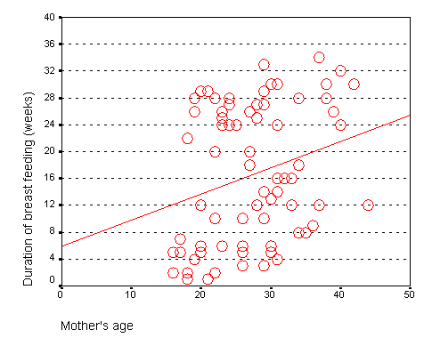

## Age vs duration - output

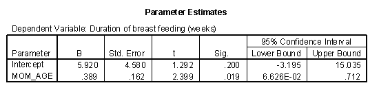

## Treatment vs duration

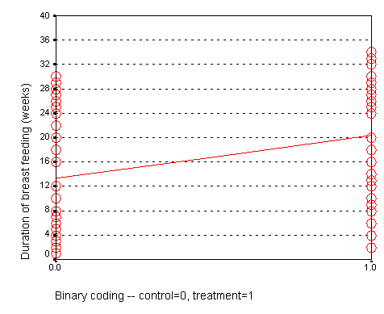

## Treatment vs duration

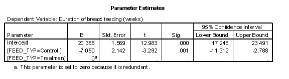

## Adjusted model

- Crude model
  - One independent variable
- Adjusted model
  - More than one independent variable
- Interpretation of slope
  - Estimated average change in Y
  - When X1 changes by one unit
  - And X2 is held contant.

## Adjusted model

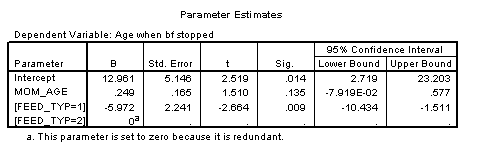

## Some alternatives

- t-test (two sample t-test)
  - Continuous outcome
  - Catregorical independent variable with two levels
- Disadvantages of the t-test
  - No risk adjustment or interactions
- Analysis of variance
  - Continuous outcome
  - Categorical independent variable with three or more levels
  - Can use more than one categorical independent variable
- Analysis of covariance
  - Second indepdent variable is continuous

## Continuous outcomes - summary

- Linear regression
  - Continuous outcome
  - Can provide risk adjustments
- Two-sample t-test
- Analysis of variance
- Analysis of covariance

## Break #6

- What you have learned
  - Linear regression
- What’s coming next
  - Logistic regression

## Logistic regression

- Binary outcome variable
- Either categorical or continuous independent variables
- Multiple variables (risk adjustment)
- Interactions

## A linear (additive) model for probability (1/4)

```
  ga pct_bf
1 28     60
2 29     62
3 30     64
4 31     66
5 32     68
6 33     70
7 34     72
```

## A linear (additive) model for probability (2/4)

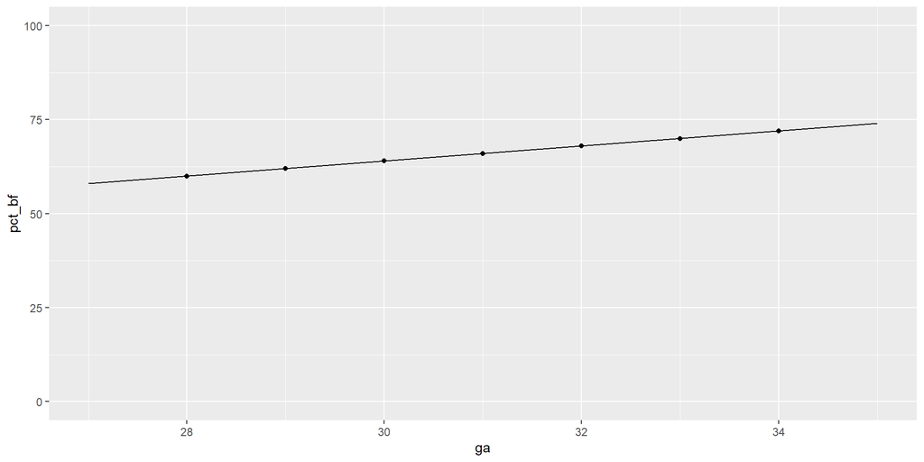

## A linear (additive) model for probability (3/4)

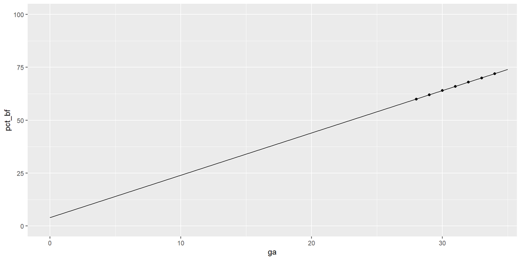

## A linear (additive) model for probability (4/4)

```
  ga pct_bf
1 28     88
2 29     91
3 30     94
4 31     97
5 32    100
6 33    103
7 34    106
```

## A multiplicative model for probability (1/3)

```
  ga pct_bf
1 28   0.01
2 29   0.03
3 30   0.09
4 31   0.27
5 32   0.81
6 33   2.43
7 34   7.29
```

## A multiplicative model for probability (2/3)

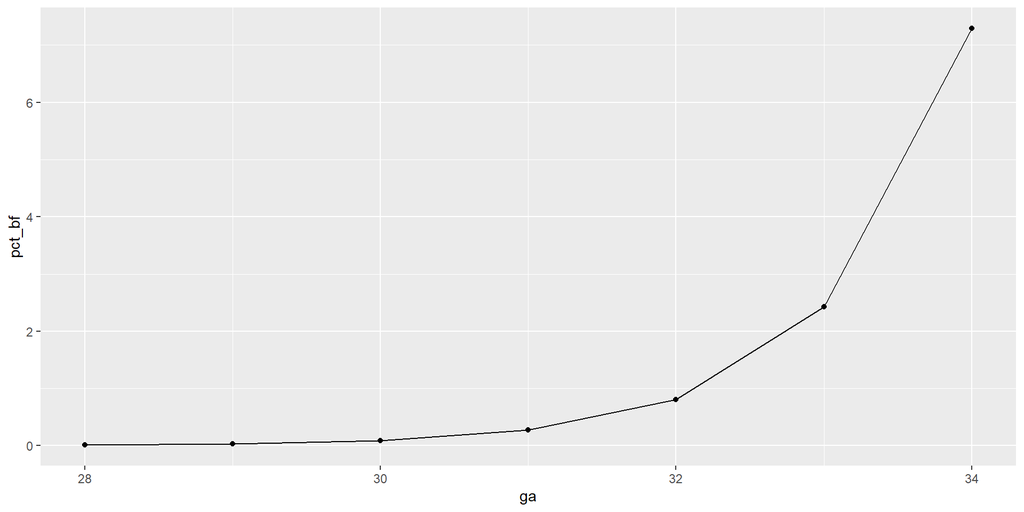

## A multiplicative model for probability (3/3)

```
  ga pct_bf
1 28   0.01
2 29   0.05
3 30   0.25
4 31   1.25
5 32   6.25
6 33  31.25
7 34 156.25
```

## The relationship between odds and probability

- Usually only seen in gambling contexts
- Sometimes ambiguous
  - Odds in favor versus odds against
- Prob = Odds / (1+Odds)
- Odds = Prob / (1-Prob)
- Examples
  - 3 to 1 odds in favor of winning
    - Prob = 3 / (3+1) = 0.75
  - 20% chance of winning
    - Odds = 0.2 / 0.8 = 1 / 4
    - Odds of 4 to 1 against

## A multiplicative odds model

```
  ga odds_bf interpretation
1 28   0.037        27 to 1
2 29   0.111         9 to 1
3 30   0.333         3 to 1
4 31   1.000         1 to 1
5 32   3.000         1 to 3
6 33   9.000         1 to 9
7 34  27.000        1 to 27
```

## Linear (additive) on log-odds scale

```
  ga odds_bf log_odds
1 28   0.037     -3.3
2 29   0.111     -2.2
3 30   0.333     -1.1
4 31   1.000      0.0
5 32   3.000      1.1
6 33   9.000      2.2
7 34  27.000      3.3
```

## The S-shaped logistic curve (1/2)

```
  ga odds_bf prob_bf
1 28   0.037   0.036
2 29   0.111   0.100
3 30   0.333   0.250
4 31   1.000   0.500
5 32   3.000   0.750
6 33   9.000   0.900
7 34  27.000   0.964
```